# Adv2020 - Day Nineteen

Tan Ho

2020-12-19

Day nineteen - Monster Messages!

```r
suppressPackageStartupMessages({
  library(tidyverse)
  library(here)
  library(glue)
  # library(furrr)
  # plan(multisession)

  knitr::opts_chunk$set(echo = TRUE)
})
  options(scipen = 9999999)
```

— Description —

> They think their satellite has collected an image of a sea monster! Unfortunately, the connection to the satellite is having problems, and many of the messages sent back from the satellite have been corrupted.

> They sent you a list of the rules valid messages should obey and a list of received messages they’ve collected so far (your puzzle input).

> Your goal is to determine the number of messages that completely match rule 0.

— Data —

```r
input_19 <- read_lines(here("2020", "day-19.txt"))

input_19_e <- read_lines(here("2020", "day-19-e.txt"))

input_19_e2 <- read_lines(here("2020", "day-19-e2.txt"))
```

— Cleaning —

Seems nice to split the list of rules into its own tibble.

```r
messages_e <- tibble(message = input_19_e) %>%
  mutate(type = cumsum(message == "")) %>%
  filter(type == 1,message !="") %>%
  select(-type)

rules_e <- tibble(rule = input_19_e) %>%
  mutate(type = cumsum(rule == "")) %>%
  filter(type == 0) %>%
  select(-type) %>%
  separate(rule,into = c("rule_id","rule_desc"), sep = ": ")

messages <- tibble(message = input_19) %>%
  mutate(type = cumsum(message == "")) %>%
  filter(type == 1,message !="") %>%
  select(-type)

rules <- tibble(rule = input_19) %>%
  mutate(type = cumsum(rule == "")) %>%
  filter(type == 0) %>%
  select(-type) %>%
  separate(rule,into = c("rule_id","rule_desc"), sep = ": ")
```

— Problem 1 —

> Your goal is to determine the number of messages that completely match rule 0.

Okay, so writing a function that loops over the rules, taking only complete rules (i.e. rules without numbers) and string-replacing them into their rule_id. Also need to add padding so that the rule id doesn’t match individual digits, and need to add parentheses for rules that have an OR condition.

```r
rule_recurse <- function(rules){

  rules <- rules %>%
    mutate(rule_desc = if_else(str_detect(rule_desc,"a|b"),
                               str_remove_all(rule_desc,'\\"'),
                               rule_desc),
           rule_id = paste0(" ",rule_id," "),
           rule_desc = paste0(" ",rule_desc," "),
           rule_desc = if_else(str_detect(rule_desc,"\\|"),
                               paste0(" ( ",rule_desc," ) "),
                               rule_desc))

  while(any(str_detect(rules$rule_desc,"[0-9]"))){

    x <- rules %>%
      filter(!str_detect(rule_desc,"[0-9]"))

    for(i in seq_along(x$rule_id)){
      rules$rule_desc <- str_replace_all(rules$rule_desc, x$rule_id[i], x$rule_desc[i])
    }
  }

  rules <- rules %>%
    mutate_all(str_remove_all," ") %>%
    mutate(rule_desc = paste0("^",rule_desc,"$"))

  return(rules)
}

rules_e1 <- rules_e %>%
  rule_recurse() %>%
  filter(rule_id == 0) %>%
  pull(rule_desc)

messages_e1 <- messages_e %>%
  mutate(match = str_detect(message,rules_e1))

p1_rules <- rules %>%
  rule_recurse() %>%
  filter(rule_id == 0) %>%
  pull(rule_desc)

p1_messages <- messages %>%
  mutate(match = str_detect(message,p1_rules))

sum(p1_messages$match)
```

```
## [1] 122
```

— Problem 2 —

> Replace 8 and 11 with new rules that create looping - how to fix?

Approach: “Pray to the regex gods and hope they find you worthy”

Deconstructing the rules changes:

8 is `42 | 42 8` - so it starts as `42`, and then when replaced with itself becomes `42 42`, `42 42 42` etc - we can represent this as “one or more of” pretty easily: `42 +` handles that condition.

11 is trickier: `42 31 | 42 11 31` means plugging `42 31` recursively into the middle of another set of 42 and 31. I spent a reading through regex recursion on this one, went to bed, continued trying regex recursion on it, until I eventually decided to hardcode `42 31 | 42 42 31 31 | 42 42 42 31 31 31` etc for like ten iterations of the loop. (I tried fifty, and got a literal stack overflow error!)

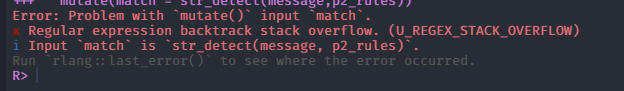

```r
messages_e2 <- tibble(message = input_19_e2) %>%
  mutate(type = cumsum(message == "")) %>%
  filter(type == 1,message !="") %>%
  select(-type)

rules_e2 <- tibble(rule = input_19_e2) %>%
  mutate(type = cumsum(rule == "")) %>%
  filter(type == 0) %>%
  select(-type) %>%
  separate(rule,into = c("rule_id","rule_desc"), sep = ": ")

rule_updater <- function(rules){
  rules %>%
    mutate(
      rule_desc = case_when(
        rule_id == "8" ~ "42 +",
        rule_id == "11" ~
          paste(
            map_chr(1:10, ~rep_len(42,.x) %>% paste(collapse = " ")),
            map_chr(1:10, ~rep_len(31,.x) %>% paste(collapse = " ")),
            collapse = " | "),
        TRUE ~ rule_desc))
}

p2_rules_e <- rules_e2 %>%
  rule_updater() %>%
  rule_recurse() %>%
  filter(rule_id == 0) %>%
  pull(rule_desc)

messages_p2_e <- messages_e2 %>%
  mutate(match = str_detect(message,p2_rules_e))

sum(messages_p2_e$match)
```

```
## [1] 12
```

```r
p2_rules <- rules %>%
  rule_updater() %>%
  rule_recurse() %>%
  filter(rule_id == 0) %>%
  pull(rule_desc)

p2_messages <- messages %>%
  mutate(match = str_detect(message, p2_rules))

sum(p2_messages$match)
```

```
## [1] 287
```

Working through the example only sort of helped: I got the example to be 12 but the actual problem ended up failing for hours. It was a good filter for bad solutions though, because when the example was wrong I knew not to bother with the actual problem.